# F0 CRISPR Screen Structure Visualisations

Minchin Lab

2026-01-30

```r
library(dplyr)
library(tidyr)
library(ggplot2)
library(patchwork)
library(forcats)
```

```r
# Load data
morph_data <- read.csv("CRISPR_screen_data_morphology_v7.csv", stringsAsFactors = FALSE)

# Standardise experiment names
morph_data$experiment <- tolower(trimws(morph_data$experiment))
morph_data$experiment <- gsub("^exp([0-9]+)$", "expt\\1", morph_data$experiment)

# Summary stats
cat("Total fish:", nrow(morph_data), "\n")
```

```
## Total fish: 1371
```

```r
cat("Genes:", length(unique(morph_data$gene)), "\n")
```

```
## Genes: 22
```

```r
cat("Experiments:", length(unique(morph_data$experiment)), "\n")
```

```
## Experiments: 3
```

# 1. Sample Size Overview

Horizontal bar chart showing sample sizes per gene, stacked by genotype.

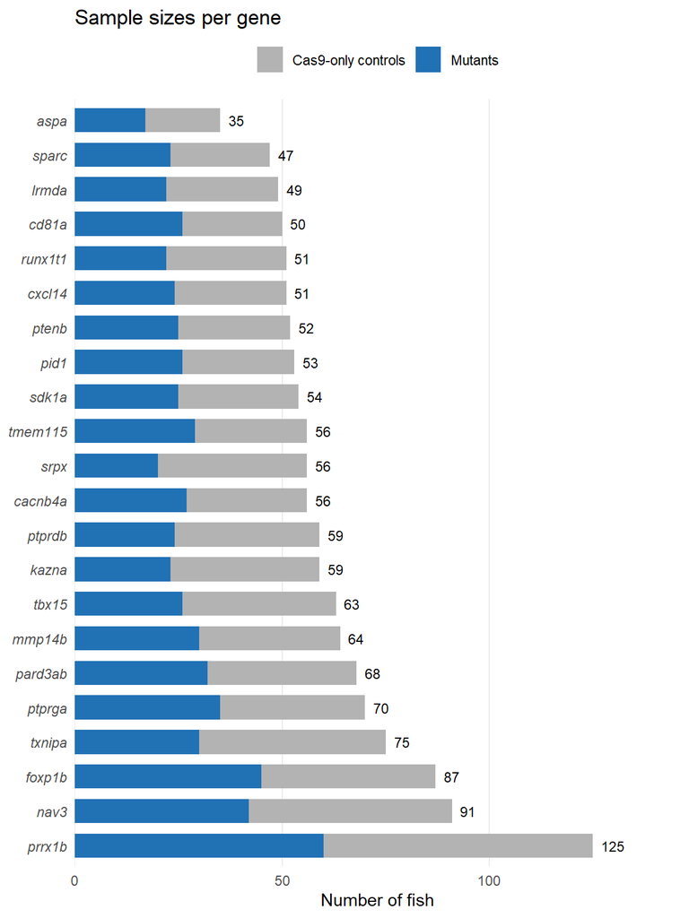

```r
# Count fish per gene and genotype
sample_counts <- morph_data %>%
  group_by(gene, genotype) %>%
  summarise(n = n(), .groups = "drop") %>%
  mutate(genotype = factor(genotype, levels = c("control", "mutant")))

# Total per gene for ordering
gene_totals <- sample_counts %>%
  group_by(gene) %>%
  summarise(total = sum(n)) %>%
  arrange(desc(total))

sample_counts$gene <- factor(sample_counts$gene, levels = gene_totals$gene)

# Colors
genotype_colors <- c("control" = "grey70", "mutant" = "#2171B5")

p_sample_size <- ggplot(sample_counts, aes(x = n, y = gene, fill = genotype)) +
  geom_col(position = "stack", width = 0.7) +
  geom_text(data = gene_totals,
            aes(x = total + 2, y = gene, label = total, fill = NULL),
            hjust = 0, size = 3) +
  scale_fill_manual(values = genotype_colors,
                    labels = c("Cas9-only controls", "Mutants")) +
  scale_x_continuous(expand = expansion(mult = c(0, 0.15))) +
  labs(x = "Number of fish", y = NULL, fill = NULL,
       title = "Sample sizes per gene") +
  theme_minimal(base_size = 11) +
  theme(
    axis.text.y = element_text(face = "italic"),
    legend.position = "top",
    panel.grid.major.y = element_blank(),
    panel.grid.minor = element_blank()
  )

print(p_sample_size)
```

```r
ggsave("screen_sample_sizes.svg", p_sample_size, width = 6, height = 8)
ggsave("screen_sample_sizes.png", p_sample_size, width = 6, height = 8, dpi = 300, bg = "white")
```

# 2. Experiment Structure Heatmap

Shows which experiments contributed data for each gene, with cell intensity = number of fish.

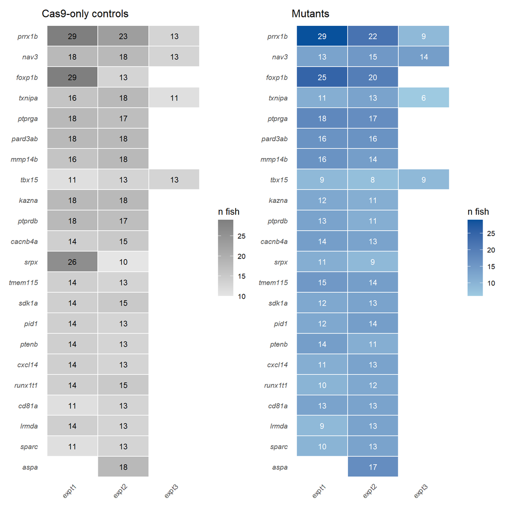

```r
# Count fish per gene × experiment × genotype
expt_structure <- morph_data %>%
  group_by(gene, experiment, genotype) %>%
  summarise(n = n(), .groups = "drop")

# Create separate heatmaps for controls and mutants
expt_ctrl <- expt_structure %>%
  filter(genotype == "control") %>%
  select(-genotype)

expt_mut <- expt_structure %>%
  filter(genotype == "mutant") %>%
  select(-genotype)

# Order genes by total n
gene_order <- morph_data %>%
  count(gene) %>%
  arrange(desc(n)) %>%
  pull(gene)

# Order experiments
expt_order <- sort(unique(morph_data$experiment))

# Mutants heatmap
p_heatmap_mut <- ggplot(expt_mut, aes(x = experiment, y = factor(gene, levels = rev(gene_order)), fill = n)) +
  geom_tile(color = "white", linewidth = 0.5) +
  geom_text(aes(label = n), color = "white", size = 3) +
  scale_fill_gradient(low = "#9ECAE1", high = "#08519C", na.value = "grey95",
                      name = "n fish") +
  labs(x = NULL, y = NULL, title = "Mutants") +
  theme_minimal(base_size = 10) +
  theme(
    axis.text.y = element_text(face = "italic"),
    axis.text.x = element_text(angle = 45, hjust = 1),
    panel.grid = element_blank(),
    legend.position = "right"
  )

# Controls heatmap
p_heatmap_ctrl <- ggplot(expt_ctrl, aes(x = experiment, y = factor(gene, levels = rev(gene_order)), fill = n)) +
  geom_tile(color = "white", linewidth = 0.5) +
  geom_text(aes(label = n), color = "black", size = 3) +
  scale_fill_gradient(low = "grey90", high = "grey50", na.value = "white",
                      name = "n fish") +
  labs(x = NULL, y = NULL, title = "Cas9-only controls") +
  theme_minimal(base_size = 10) +
  theme(
    axis.text.y = element_text(face = "italic"),
    axis.text.x = element_text(angle = 45, hjust = 1),
    panel.grid = element_blank(),
    legend.position = "right"
  )

p_heatmap_combined <- p_heatmap_ctrl | p_heatmap_mut
print(p_heatmap_combined)
```

```r
ggsave("screen_experiment_structure.svg", p_heatmap_combined, width = 10, height = 8)
ggsave("screen_experiment_structure.png", p_heatmap_combined, width = 10, height = 8, dpi = 300, bg = "white")
```

# 3. Replicate Consistency Plot

For genes with multiple experiments, shows how experiment means compare.

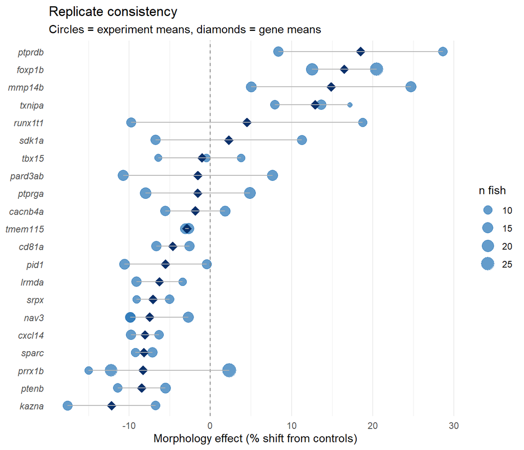

```r
# Calculate mean morphology value per gene × experiment
# First need to calculate morphology values
library(mgcv)

# Fit GAM on controls
all_controls <- morph_data %>% filter(genotype == "control")
all_controls$log_feret <- log(all_controls$mean_feret)
all_controls$log_area <- log(all_controls$total_adipose_area)
gam_model <- gam(log_feret ~ s(log_area), data = all_controls)

# Calculate morphology value
morph_data$log_feret <- log(morph_data$mean_feret)
morph_data$log_area <- log(morph_data$total_adipose_area)
morph_data$predicted <- predict(gam_model, newdata = morph_data)
morph_data$morph_value <- (exp(morph_data$log_feret - morph_data$predicted) - 1) * 100

# Center on control mean per gene
ctrl_means <- morph_data %>%
  filter(genotype == "control") %>%
  group_by(gene) %>%
  summarise(ctrl_mean = mean(morph_value))

morph_data <- morph_data %>%
  left_join(ctrl_means, by = "gene") %>%
  mutate(morph_centered = morph_value - ctrl_mean)

# Experiment means for mutants
expt_means <- morph_data %>%
  filter(genotype == "mutant") %>%
  group_by(gene, experiment) %>%
  summarise(
    mean_morph = mean(morph_centered),
    n = n(),
    se = sd(morph_centered) / sqrt(n()),
    .groups = "drop"
  )

# Gene means
gene_means <- expt_means %>%
  group_by(gene) %>%
  summarise(
    overall_mean = mean(mean_morph),
    n_expts = n(),
    .groups = "drop"
  ) %>%
  filter(n_expts >= 2)  # Only genes with 2+ experiments

# Filter to multi-experiment genes
expt_means_multi <- expt_means %>%
  filter(gene %in% gene_means$gene)

# Order by overall effect
gene_order_effect <- gene_means %>% arrange(overall_mean) %>% pull(gene)
expt_means_multi$gene <- factor(expt_means_multi$gene, levels = gene_order_effect)
gene_means$gene <- factor(gene_means$gene, levels = gene_order_effect)

p_consistency <- ggplot() +
  # Experiment means as points
  geom_point(data = expt_means_multi,
             aes(x = mean_morph, y = gene, size = n),
             color = "#2171B5", alpha = 0.7) +
  # Gene overall mean as diamond
  geom_point(data = gene_means,
             aes(x = overall_mean, y = gene),
             shape = 18, size = 4, color = "#08306B") +
  # Reference line at 0
  geom_vline(xintercept = 0, linetype = "dashed", color = "grey50") +
  # Connect experiments within genes
  geom_line(data = expt_means_multi,
            aes(x = mean_morph, y = gene, group = gene),
            color = "grey70", linewidth = 0.5) +
  scale_size_continuous(range = c(2, 6), name = "n fish") +
  labs(x = "Morphology effect (% shift from controls)", y = NULL,
       title = "Replicate consistency",
       subtitle = "Circles = experiment means, diamonds = gene means") +
  theme_minimal(base_size = 11) +
  theme(
    axis.text.y = element_text(face = "italic"),
    panel.grid.major.y = element_blank(),
    legend.position = "right"
  )

print(p_consistency)
```

```r
ggsave("screen_replicate_consistency.svg", p_consistency, width = 7, height = 6)
ggsave("screen_replicate_consistency.png", p_consistency, width = 7, height = 6, dpi = 300, bg = "white")
```

# 4. Replicate Quality Score

Combines consistency and direction agreement across all measures (SL, Normalised Adiposity, Morphology) into a single quality score. Higher = more reproducible.

```r
# Load all measures data for SL and norm adiposity
all_data <- read.csv("CRISPR_screen_data_all_measures_v7.csv", stringsAsFactors = FALSE)

# Standardise experiment names in all_data
standardise_exp <- function(exp) {
  exp <- tolower(trimws(as.character(exp)))
  # Handle '1.0', '2.0' etc
  if (grepl("^[0-9]+(\\.[0-9]+)?$", exp)) {
    num <- as.integer(as.numeric(exp))
    return(paste0("expt", num))
  }
  # Handle 'exp1', 'expt1' etc
  if (grepl("^exp[0-9]", exp) && !grepl("^expt", exp)) {
    return(sub("^exp", "expt", exp))
  }
  return(exp)
}
all_data$experiment <- sapply(all_data$experiment, standardise_exp)

# Calculate SL effect per gene × experiment
sl_data <- all_data %>% filter(measure == "SL_um")
sl_effects <- sl_data %>%
  group_by(gene, experiment) %>%
  summarise(
    ctrl_mean = mean(value[genotype == "control"]),
    mut_mean = mean(value[genotype == "mutant"]),
    .groups = "drop"
  ) %>%
  filter(!is.na(ctrl_mean) & !is.na(mut_mean)) %>%
  mutate(SL_effect = (mut_mean - ctrl_mean) / ctrl_mean * 100) %>%
  select(gene, experiment, SL_effect)

# Calculate Norm Adiposity effect per gene × experiment
norm_data <- all_data %>% filter(measure == "norm_adiposity")
norm_effects <- norm_data %>%
  group_by(gene, experiment) %>%
  summarise(
    ctrl_mean = mean(value[genotype == "control"]),
    mut_mean = mean(value[genotype == "mutant"]),
    .groups = "drop"
  ) %>%
  filter(!is.na(ctrl_mean) & !is.na(mut_mean)) %>%
  mutate(Norm_effect = (mut_mean - ctrl_mean) / ctrl_mean * 100) %>%
  select(gene, experiment, Norm_effect)

# Get morphology effects from expt_means (already calculated)
morph_effects <- expt_means %>%
  select(gene, experiment, Morph_effect = mean_morph)

# Merge all effects
effects <- sl_effects %>%
  inner_join(norm_effects, by = c("gene", "experiment")) %>%
  inner_join(morph_effects, by = c("gene", "experiment"))

cat("Gene × experiment combinations with all measures:", nrow(effects), "\n")
```

```
## Gene × experiment combinations with all measures: 47
```

```r
# Calculate quality score per gene
calc_rep_consistency <- function(vals) {
  if (length(vals) < 2) return(0.5)  # Single replicate - unknown
  val_range <- max(vals) - min(vals)
  # Score of 1 = no spread, 0 = huge spread (>50%)
  max(0, 1 - val_range / 50)
}

calc_direction_consistency <- function(vals) {
  if (length(vals) < 2) return(0.5)  # Single replicate - unknown
  signs <- sign(vals)
  # All same sign = 1, mixed = 0
  if (all(signs >= 0) || all(signs <= 0)) return(1.0) else return(0.0)
}

# Calculate scores per gene
gene_quality <- effects %>%
  group_by(gene) %>%
  summarise(
    n_reps = n(),
    SL_consist = calc_rep_consistency(SL_effect),
    Norm_consist = calc_rep_consistency(Norm_effect),
    Morph_consist = calc_rep_consistency(Morph_effect),
    SL_dir = calc_direction_consistency(SL_effect),
    Norm_dir = calc_direction_consistency(Norm_effect),
    Morph_dir = calc_direction_consistency(Morph_effect),
    .groups = "drop"
  ) %>%
  mutate(
    avg_consistency = (SL_consist + Norm_consist + Morph_consist) / 3,
    avg_direction = (SL_dir + Norm_dir + Morph_dir) / 3,
    quality_score = (avg_consistency + avg_direction) / 2 * 100
  ) %>%
  arrange(desc(quality_score))

cat("\nReplicate Quality Scores:\n")
```

```
##
## Replicate Quality Scores:
```

```r
print(gene_quality %>% select(gene, n_reps, avg_consistency, avg_direction, quality_score) %>%
        mutate(across(where(is.numeric), ~round(., 2))))
```

```
## # A tibble: 22 × 5
##    gene    n_reps avg_consistency avg_direction quality_score
##    <chr>    <dbl>           <dbl>         <dbl>         <dbl>
##  1 tmem115      2            0.96          1             98
##  2 kazna        2            0.71          1             85.5
##  3 txnipa       3            0.63          1             81.6
##  4 cd81a        2            0.88          0.67          77.2
##  5 sparc        2            0.85          0.67          76.0
##  6 pid1         2            0.77          0.67          71.7
##  7 sdk1a        2            0.77          0.67          71.7
##  8 pard3ab      2            0.76          0.67          71.3
##  9 mmp14b       2            0.75          0.67          70.8
## 10 foxp1b       2            0.73          0.67          69.7
## # ℹ 12 more rows
```

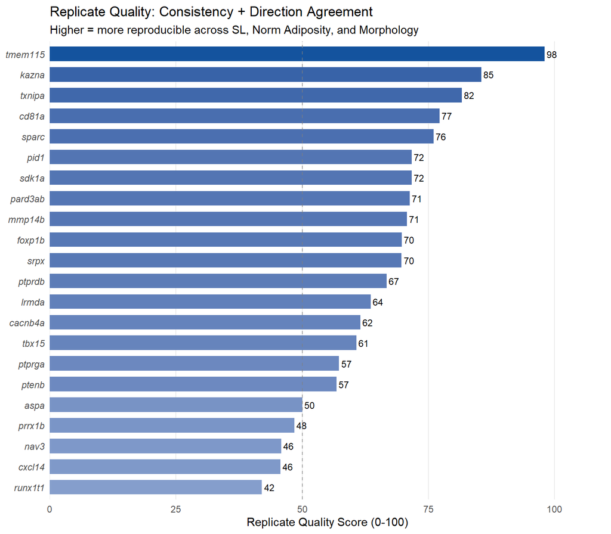

```r
# Plot with blue color scheme
gene_quality$gene <- factor(gene_quality$gene, levels = rev(gene_quality$gene))

# Blue gradient based on score
p_quality <- ggplot(gene_quality, aes(x = quality_score, y = gene, fill = quality_score)) +
  geom_col(width = 0.7) +
  geom_text(aes(label = sprintf("%.0f", quality_score)), hjust = -0.2, size = 3) +
  scale_fill_gradient(low = "#C6DBEF", high = "#08519C",
                      limits = c(0, 100), guide = "none") +
  geom_vline(xintercept = 50, linetype = "dashed", color = "grey50", alpha = 0.7) +
  scale_x_continuous(limits = c(0, 110), expand = c(0, 0)) +
  labs(x = "Replicate Quality Score (0-100)", y = NULL,
       title = "Replicate Quality: Consistency + Direction Agreement",
       subtitle = "Higher = more reproducible across SL, Norm Adiposity, and Morphology") +
  theme_minimal(base_size = 11) +
  theme(
    axis.text.y = element_text(face = "italic"),
    panel.grid.major.y = element_blank(),
    panel.grid.minor = element_blank()
  )

print(p_quality)
```

```r
ggsave("screen_replicate_quality.svg", p_quality, width = 8, height = 7)
ggsave("screen_replicate_quality.png", p_quality, width = 8, height = 7, dpi = 300, bg = "white")
```

# 5. Dumbbell Plot

Control vs mutant means connected by lines - line length = effect size.

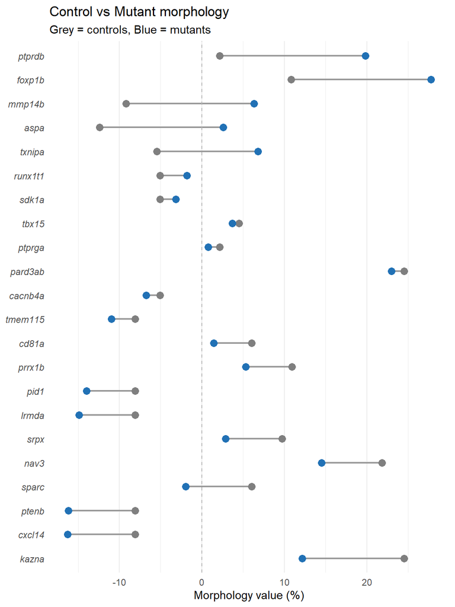

```r
# Calculate genotype means per gene
genotype_means <- morph_data %>%
  group_by(gene, genotype) %>%
  summarise(mean_morph = mean(morph_value), .groups = "drop") %>%
  pivot_wider(names_from = genotype, values_from = mean_morph) %>%
  mutate(effect = mutant - control) %>%
  arrange(effect)

genotype_means$gene <- factor(genotype_means$gene, levels = genotype_means$gene)

# Reshape for plotting
dumbbell_data <- genotype_means %>%
  pivot_longer(cols = c(control, mutant), names_to = "genotype", values_to = "mean_morph")

p_dumbbell <- ggplot() +
  # Connecting lines
  geom_segment(data = genotype_means,
               aes(x = control, xend = mutant, y = gene, yend = gene),
               color = "grey60", linewidth = 0.8) +
  # Control points
  geom_point(data = genotype_means,
             aes(x = control, y = gene),
             color = "grey50", size = 3) +
  # Mutant points
  geom_point(data = genotype_means,
             aes(x = mutant, y = gene),
             color = "#2171B5", size = 3) +
  # Reference line at 0
  geom_vline(xintercept = 0, linetype = "dashed", color = "grey70") +
  labs(x = "Morphology value (%)", y = NULL,
       title = "Control vs Mutant morphology",
       subtitle = "Grey = controls, Blue = mutants") +
  theme_minimal(base_size = 11) +
  theme(
    axis.text.y = element_text(face = "italic"),
    panel.grid.major.y = element_blank()
  )

print(p_dumbbell)
```

```r
ggsave("screen_dumbbell.svg", p_dumbbell, width = 6, height = 8)
ggsave("screen_dumbbell.png", p_dumbbell, width = 6, height = 8, dpi = 300, bg = "white")
```

# 6. Screening Funnel/Sankey Diagram

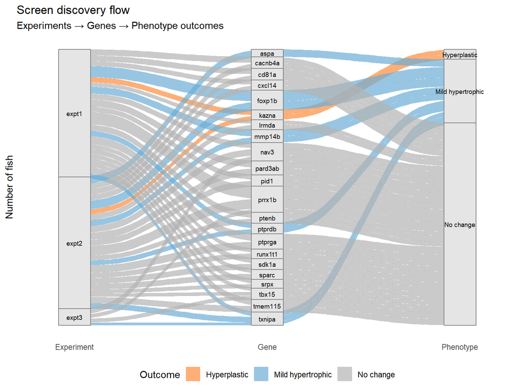

```r
# Calculate summary stats (used here and later)
total_fish <- nrow(morph_data)
n_genes <- length(unique(morph_data$gene))
n_mutants <- sum(morph_data$genotype == "mutant")
n_controls <- sum(morph_data$genotype == "control")
n_experiments <- length(unique(morph_data$experiment))

# For Sankey we need the ggsankey or ggalluvial package
# Using ggalluvial which is more commonly available

if (!requireNamespace("ggalluvial", quietly = TRUE)) {
  message("Installing ggalluvial...")
  install.packages("ggalluvial", repos = "https://cloud.r-project.org")
}
library(ggalluvial)

# Create flow data
# We need: Fish → Gene → Phenotype outcome

# Simplified version: show flow from experiments to genes to significance
# First, let's create the data structure

# For a proper Sankey, let's show:
# Experiments → Genes → Phenotype (significant vs not)

# Calculate which genes have significant effects (placeholder - update with real stats)
# For now, let's use morphology effect > 15% as "hit"
gene_effects <- morph_data %>%
  filter(genotype == "mutant") %>%
  group_by(gene) %>%
  summarise(mean_effect = mean(morph_centered), .groups = "drop") %>%
  mutate(outcome = case_when(
    mean_effect > 20 ~ "Strong hypertrophic",
    mean_effect > 10 ~ "Mild hypertrophic",
    mean_effect < -10 ~ "Hyperplastic",
    TRUE ~ "No change"
  ))

# Create alluvial data
sankey_data <- morph_data %>%
  filter(genotype == "mutant") %>%
  left_join(gene_effects %>% select(gene, outcome), by = "gene") %>%
  count(experiment, gene, outcome)

# Simplified 2-stage Sankey: Gene → Outcome
sankey_simple <- gene_effects %>%
  count(outcome) %>%
  mutate(
    stage1 = "Genes tested",
    stage2 = outcome
  )

# Create alluvial plot
p_sankey <- ggplot(sankey_data,
       aes(axis1 = experiment, axis2 = gene, axis3 = outcome, y = n)) +
  geom_alluvium(aes(fill = outcome), width = 1/12, alpha = 0.7) +
  geom_stratum(width = 1/6, fill = "grey90", color = "grey50") +
  geom_text(stat = "stratum", aes(label = after_stat(stratum)), size = 2.5) +
  scale_x_discrete(limits = c("Experiment", "Gene", "Phenotype"), expand = c(0.1, 0.1)) +
  scale_fill_manual(values = c(
    "Strong hypertrophic" = "#08519C",
    "Mild hypertrophic" = "#6BAED6",
    "No change" = "grey70",
    "Hyperplastic" = "#FD8D3C"
  )) +
  labs(title = "Screen discovery flow",
       subtitle = "Experiments → Genes → Phenotype outcomes",
       y = "Number of fish", fill = "Outcome") +
  theme_minimal(base_size = 11) +
  theme(
    legend.position = "bottom",
    panel.grid = element_blank(),
    axis.text.y = element_blank()
  )

print(p_sankey)
```

```r
ggsave("screen_sankey.svg", p_sankey, width = 10, height = 7)
ggsave("screen_sankey.png", p_sankey, width = 10, height = 7, dpi = 300, bg = "white")
```

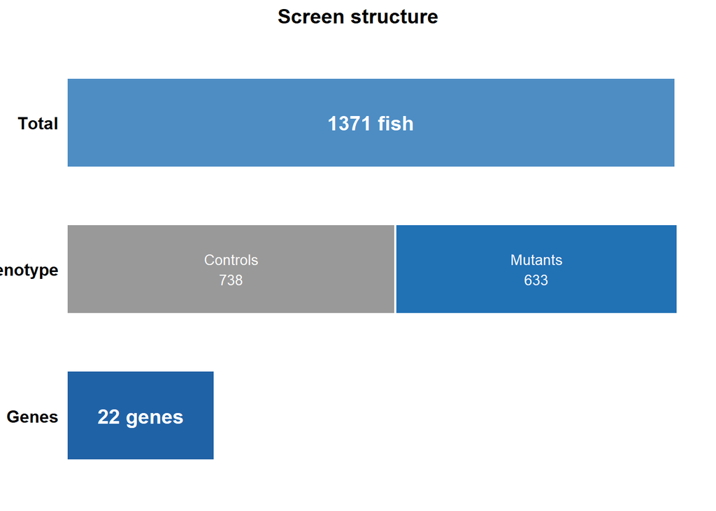

```r
# Simpler 2-node Sankey: Genes → Outcomes
sankey_genes <- gene_effects %>%
  mutate(source = "Genes screened") %>%
  count(source, outcome, name = "value")

# Alternative: use networkD3 for interactive Sankey
if (!requireNamespace("networkD3", quietly = TRUE)) {
  message("For interactive Sankey, install networkD3")
}

# Static version using geom_col with curved connections
# Create a cleaner "funnel" style flow

flow_summary <- data.frame(
  from_stage = c(rep("Fish screened", 2), rep("Genes tested", 4)),
  to_stage = c("Controls", "Mutants",
               "Strong hypertrophic", "Mild hypertrophic", "No change", "Hyperplastic"),
  n = c(n_controls, n_mutants,
        sum(gene_effects$outcome == "Strong hypertrophic"),
        sum(gene_effects$outcome == "Mild hypertrophic"),
        sum(gene_effects$outcome == "No change"),
        sum(gene_effects$outcome == "Hyperplastic"))
)

# Horizontal bar representation of flow
p_flow <- ggplot() +
  # Total fish bar
  annotate("rect", xmin = 0, xmax = total_fish, ymin = 2.7, ymax = 3.3,
           fill = "#2171B5", alpha = 0.8) +
  annotate("text", x = total_fish/2, y = 3, label = paste(total_fish, "fish"),
           color = "white", fontface = "bold", size = 5) +


  # Split: controls vs mutants
 annotate("rect", xmin = 0, xmax = n_controls, ymin = 1.7, ymax = 2.3,
           fill = "grey60") +
  annotate("text", x = n_controls/2, y = 2,
           label = paste0("Controls\n", n_controls), color = "white", size = 3.5) +
  annotate("rect", xmin = n_controls + 5, xmax = n_controls + 5 + n_mutants,
           ymin = 1.7, ymax = 2.3, fill = "#2171B5") +
  annotate("text", x = n_controls + 5 + n_mutants/2, y = 2,
           label = paste0("Mutants\n", n_mutants), color = "white", size = 3.5) +

  # Genes bar
  annotate("rect", xmin = 0, xmax = n_genes * 15, ymin = 0.7, ymax = 1.3,
           fill = "#08519C", alpha = 0.9) +
  annotate("text", x = n_genes * 15 / 2, y = 1,
           label = paste(n_genes, "genes"), color = "white", fontface = "bold", size = 5) +

  # Labels
  annotate("text", x = -20, y = 3, label = "Total", hjust = 1, fontface = "bold") +
  annotate("text", x = -20, y = 2, label = "Genotype", hjust = 1, fontface = "bold") +
  annotate("text", x = -20, y = 1, label = "Genes", hjust = 1, fontface = "bold") +

  scale_y_continuous(limits = c(0.5, 3.5)) +
  scale_x_continuous(limits = c(-80, total_fish + 20)) +
  labs(title = "Screen structure") +
  theme_void(base_size = 12) +
  theme(plot.title = element_text(hjust = 0.5, face = "bold"))

print(p_flow)
```

```r
ggsave("screen_flow_simple.svg", p_flow, width = 8, height = 4)
ggsave("screen_flow_simple.png", p_flow, width = 8, height = 4, dpi = 300, bg = "white")
```

# 7. Screening Funnel Summary

Visual summary of the screen scale (simple bar chart version).

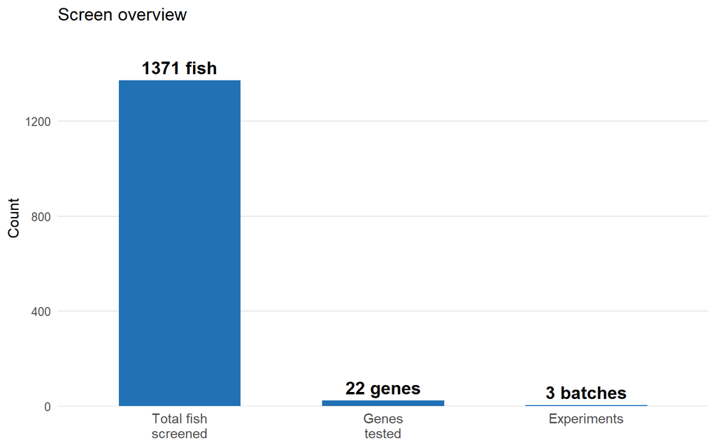

```r
# Variables already calculated in Sankey section above

# For significant hits, we'd need the stats - estimate based on typical results
# You can update these numbers based on actual results
funnel_data <- data.frame(
  stage = c("Total fish\nscreened", "Genes\ntested", "Experiments"),
  value = c(total_fish, n_genes, n_experiments),
  label = c(paste0(total_fish, " fish"), paste0(n_genes, " genes"), paste0(n_experiments, " batches"))
)

funnel_data$stage <- factor(funnel_data$stage, levels = funnel_data$stage)

# Simple pictogram-style summary
p_funnel <- ggplot(funnel_data, aes(x = stage, y = value)) +
  geom_col(fill = "#2171B5", width = 0.6) +
  geom_text(aes(label = label), vjust = -0.5, size = 5, fontface = "bold") +
  scale_y_continuous(expand = expansion(mult = c(0, 0.15))) +
  labs(x = NULL, y = "Count", title = "Screen overview") +
  theme_minimal(base_size = 12) +
  theme(
    panel.grid.major.x = element_blank(),
    panel.grid.minor = element_blank(),
    axis.text.x = element_text(size = 11)
  )

print(p_funnel)
```

```r
ggsave("screen_funnel.svg", p_funnel, width = 6, height = 4)
ggsave("screen_funnel.png", p_funnel, width = 6, height = 4, dpi = 300, bg = "white")
```

# 8. Fish Pictogram (Waffle Chart)

Each square represents fish, colored by genotype.

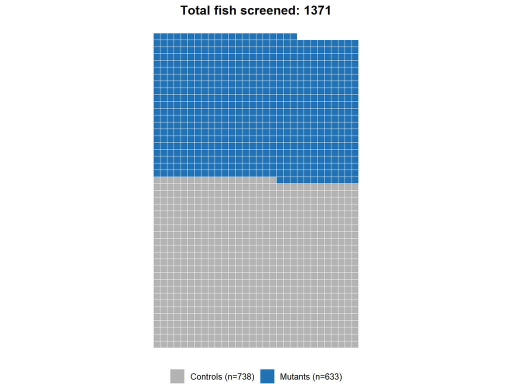

```r
# Create waffle-style data
# Round to nearest 10 for cleaner visualization
n_ctrl_round <- round(n_controls / 10) * 10
n_mut_round <- round(n_mutants / 10) * 10

# Create grid
waffle_data <- data.frame(
  genotype = c(rep("control", n_controls), rep("mutant", n_mutants))
)

# Add position
n_cols <- 30
waffle_data <- waffle_data %>%
  mutate(
    idx = row_number(),
    x = ((idx - 1) %% n_cols) + 1,
    y = ((idx - 1) %/% n_cols) + 1
  )

p_waffle <- ggplot(waffle_data, aes(x = x, y = y, fill = genotype)) +
  geom_tile(color = "white", linewidth = 0.3) +
  scale_fill_manual(values = c("control" = "grey70", "mutant" = "#2171B5"),
                    labels = c(paste0("Controls (n=", n_controls, ")"),
                              paste0("Mutants (n=", n_mutants, ")"))) +
  coord_equal() +
  labs(title = paste("Total fish screened:", total_fish),
       fill = NULL) +
  theme_void(base_size = 12) +
  theme(
    legend.position = "bottom",
    plot.title = element_text(hjust = 0.5, face = "bold")
  )

print(p_waffle)
```

```r
ggsave("screen_waffle.svg", p_waffle, width = 8, height = 6)
ggsave("screen_waffle.png", p_waffle, width = 8, height = 6, dpi = 300, bg = "white")
```

# 9. Combined Summary Figure

A polished combined figure for the paper.

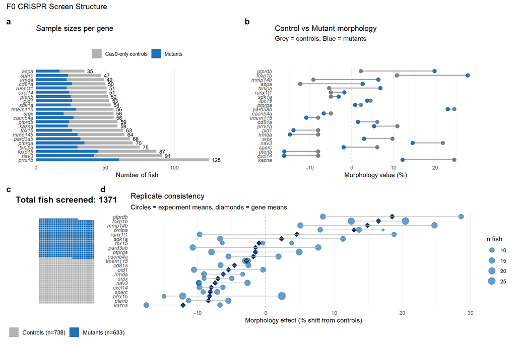

```r
# Combine key plots
p_combined <- (p_sample_size | p_dumbbell) /
              (p_waffle | p_consistency) +
  plot_annotation(
    title = "F0 CRISPR Screen Structure",
    tag_levels = "a"
  ) &
  theme(plot.tag = element_text(face = "bold", size = 14))

print(p_combined)
```

```r
ggsave("screen_structure_combined.svg", p_combined, width = 12, height = 10)
ggsave("screen_structure_combined.png", p_combined, width = 12, height = 10, dpi = 300, bg = "white")
```

# Output Files

```r
cat("
**Individual plots:**

- `screen_sample_sizes.svg/png` - Sample sizes per gene
- `screen_experiment_structure.svg/png` - Experiment × gene heatmap
- `screen_replicate_consistency.svg/png` - Replicate consistency
- `screen_replicate_quality.svg/png` - Replicate quality score (consistency + direction)
- `screen_dumbbell.svg/png` - Control vs mutant dumbbell plot
- `screen_sankey.svg/png` - Sankey/alluvial diagram (experiments → genes → outcomes)
- `screen_flow_simple.svg/png` - Simple flow diagram
- `screen_funnel.svg/png` - Screen overview bars
- `screen_waffle.svg/png` - Fish pictogram

**Combined:**

- `screen_structure_combined.svg/png` - Multi-panel summary figure
")
```

**Individual plots:**

- `screen_sample_sizes.svg/png` - Sample sizes per gene
- `screen_experiment_structure.svg/png` - Experiment × gene heatmap
- `screen_replicate_consistency.svg/png` - Replicate consistency
- `screen_replicate_quality.svg/png` - Replicate quality score (consistency + direction)
- `screen_dumbbell.svg/png` - Control vs mutant dumbbell plot
- `screen_sankey.svg/png` - Sankey/alluvial diagram (experiments → genes → outcomes)
- `screen_flow_simple.svg/png` - Simple flow diagram
- `screen_funnel.svg/png` - Screen overview bars
- `screen_waffle.svg/png` - Fish pictogram

**Combined:**

- `screen_structure_combined.svg/png` - Multi-panel summary figure